# 市场观察

## D、择时

### (d1)等权指数

从历史来看，A股市场存在小盘股效应，市值小的股票长期整体跑赢大市值的股票，美股市场同样存在类似的现象。而目前大部分指数的编制方案都是类似市值加权，为了抛去市值的影响，下面展示几个等权指数，其中中证500等权和沪深300等权是现有的指数，中证全指等权是自己编制的指数。等权指数可以视为一个更好地业绩比较基准。等权指数走势如下图：

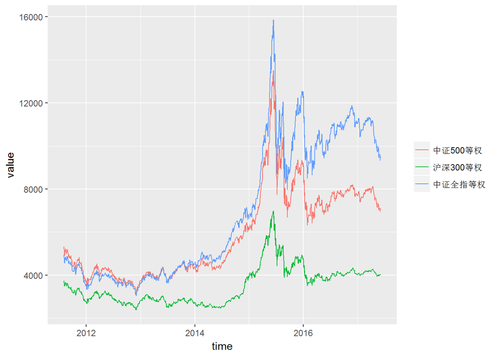

等权指数收益率统计见下表：

|  | 中证500等权 | 沪深300等权 | 中证全指等权 |
| --- | --- | --- | --- |
| 2011-08-02 ~ 2011-12-30 | -29.2% | -25.5% | -27.8% |
| 2012-01-04 ~ 2012-12-31 | -0.0% | 1.5% | 2.2% |
| 2013-01-04 ~ 2013-12-31 | 16.7% | -3.2% | 25.8% |
| 2014-01-02 ~ 2014-12-31 | 40.2% | 43.7% | 46.0% |
| 2015-01-05 ~ 2015-12-31 | 47.6% | 20.1% | 84.4% |
| 2016-01-04 ~ 2016-12-30 | -15.1% | -15.1% | -10.3% |
| 2017-01-03 ~ 2017-06-05 | -8.1% | -0.5% | -13.9% |
| 累计收益率 | 33.4% | 6.9% | 93.1% |
| 年化收益率 | 5.1% | 1.1% | 11.9% |
| 年化波动率 | 28.5% | 25.7% | 28.8% |
| 年化Sharpe值 | 17.8% | 4.5% | 41.3% |
| 最大回撤 | 53.3% | 50.0% | 49.7% |

### (d2)大盘均线强弱指数

大盘均线强弱指数在一定程度上可以视为一个反转指标，当大盘均线得分接近8分时，预示市场接近顶部，当大盘均线得分接近0分时，预示市场接近底部。  
大盘均线强弱指数近一年来走势如下图：

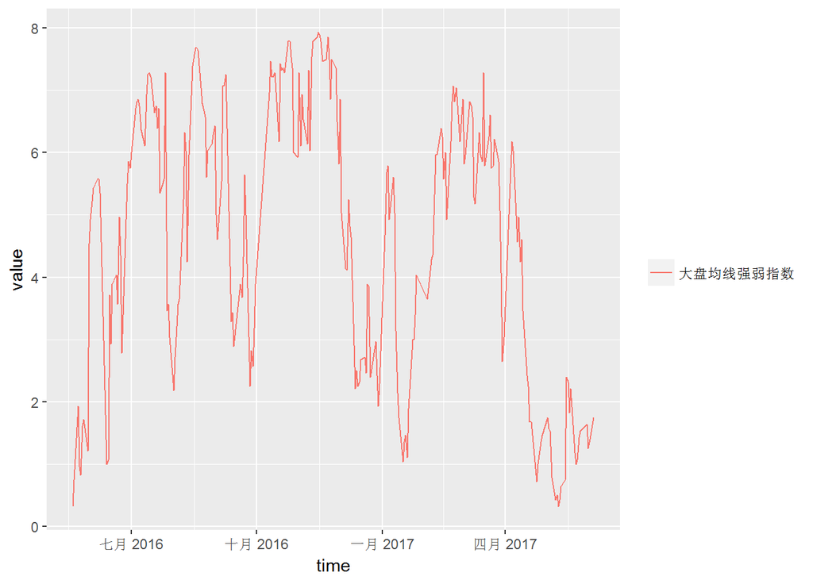

申万一级行业的最新得分见下表：

| 日期 | 指数代码 | 行业 | 最新得分 | 上周得分 |
| --- | --- | --- | --- | --- |
| 2017-06-05 | EI801110 | 家用电器 | 8 | 8 |
| 2017-06-05 | EI801790 | 非银金融 | 8 | 8 |
| 2017-06-05 | EI801780 | 银行 | 7 | 8 |
| 2017-06-05 | EI801120 | 食品饮料 | 5 | 8 |
| 2017-06-05 | EI801020 | 采掘 | 3 | 3 |
| 2017-06-05 | EI801180 | 房地产 | 3 | 2 |
| 2017-06-05 | EI801720 | 建筑装饰 | 2 | 1 |
| 2017-06-05 | EI801040 | 钢铁 | 1 | 4 |
| 2017-06-05 | EI801080 | 电子 | 1 | 0 |
| 2017-06-05 | EI801140 | 轻工制造 | 1 | 0 |
| 2017-06-05 | EI801160 | 公用事业 | 1 | 0 |
| 2017-06-05 | EI801170 | 交通运输 | 1 | 0 |
| 2017-06-05 | EI801200 | 商业贸易 | 1 | 0 |
| 2017-06-05 | EI801210 | 休闲服务 | 1 | 0 |
| 2017-06-05 | EI801730 | 电气设备 | 1 | 0 |
| 2017-06-05 | EI801740 | 国防军工 | 1 | 0 |
| 2017-06-05 | EI801750 | 计算机 | 1 | 0 |
| 2017-06-05 | EI801760 | 传媒 | 1 | 0 |
| 2017-06-05 | EI801770 | 通信 | 1 | 0 |
| 2017-06-05 | EI801880 | 汽车 | 1 | 0 |
| 2017-06-05 | EI801010 | 农林牧渔 | 0 | 0 |
| 2017-06-05 | EI801030 | 化工 | 0 | 0 |
| 2017-06-05 | EI801050 | 有色金属 | 0 | 0 |
| 2017-06-05 | EI801130 | 纺织服装 | 0 | 0 |
| 2017-06-05 | EI801150 | 医药生物 | 0 | 0 |
| 2017-06-05 | EI801230 | 综合 | 0 | 0 |
| 2017-06-05 | EI801710 | 建筑材料 | 0 | 1 |
| 2017-06-05 | EI801890 | 机械设备 | 0 | 0 |

### (d3)LLT及均线择时

LLT本质上是一个改进的单均线择时指标，较原始的均线择时延迟更低。  
择时模型和指数本身的净值走势如下图：

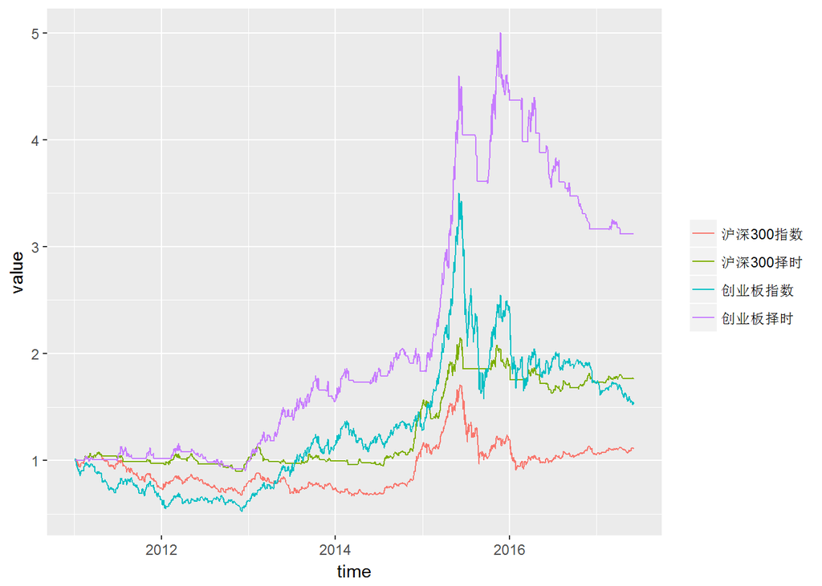

择时模型和指数的收益率统计如下表：

|  | 沪深300指 | 沪深300LLT | 创业板指 | 创业板MA |
| --- | --- | --- | --- | --- |
| 2011-01-04 ~ 2011-12-30 | -25.0% | -2.5% | -35.9% | 1.9% |
| 2012-01-04 ~ 2012-12-31 | 7.6% | 5.4% | -2.1% | -1.7% |
| 2013-01-04 ~ 2013-12-31 | -7.6% | -3.2% | 82.7% | 55.7% |
| 2014-01-02 ~ 2014-12-31 | 51.7% | 52.4% | 12.8% | 17.7% |
| 2015-01-05 ~ 2015-12-31 | 5.6% | 24.3% | 84.4% | 138.1% |
| 2016-01-04 ~ 2016-12-30 | -11.3% | -8.1% | -27.7% | -27.5% |
| 2017-01-03 ~ 2017-06-05 | 4.8% | 1.5% | -10.2% | -1.6% |
| 累计收益率 | 10.9% | 76.0% | 54.8% | 211.7% |
| 年化收益率 | 1.6% | 9.2% | 7.0% | 19.4% |
| 年化波动率 | 23.8% | 15.3% | 32.5% | 21.8% |
| 年化Sharpe值 | 6.8% | 60.2% | 21.7% | 88.8% |
| 最大回撤 | 46.7% | 24.0% | 56.6% | 37.7% |

择时模型最近10个交易日的信号如下表：

| 日期 | 沪深300收盘价 | 沪深300LLT | 沪深300择时信号 | 创业板收盘价 | 创业板MA30 | 创业板择时信号 |
| --- | --- | --- | --- | --- | --- | --- |
| 2017-05-19 | 3403.849 | 3431.615 |  | 1801.078 | 1838.457 |  |
| 2017-05-22 | 3411.239 | 3430.206 |  | 1788.075 | 1833.191 |  |
| 2017-05-23 | 3424.194 | 3429.525 |  | 1758.235 | 1828.051 |  |
| 2017-05-24 | 3424.167 | 3429.296 |  | 1776.278 | 1823.339 |  |
| 2017-05-25 | 3485.658 | 3431.075 | buy | 1777.694 | 1819.345 |  |
| 2017-05-26 | 3480.434 | 3434.595 | hold | 1759.632 | 1814.317 |  |
| 2017-05-31 | 3492.885 | 3438.174 | hold | 1763.729 | 1810.193 |  |
| 2017-06-01 | 3497.738 | 3442.138 | hold | 1728.488 | 1805.533 |  |
| 2017-06-02 | 3486.507 | 3445.696 | hold | 1745.927 | 1802.124 |  |
| 2017-06-05 | 3468.754 | 3448.131 | hold | 1761.246 | 1799.319 |  |

### (d4)网格交易

在经历了三轮股灾，A股逐步回归正常，在过去的一段时间呈现一个震荡的格局，如果未来没有增量信息，很可能维持震荡。结合股指期货的贴水，前期研究了一下网格交易。网格交易的结果如下图：

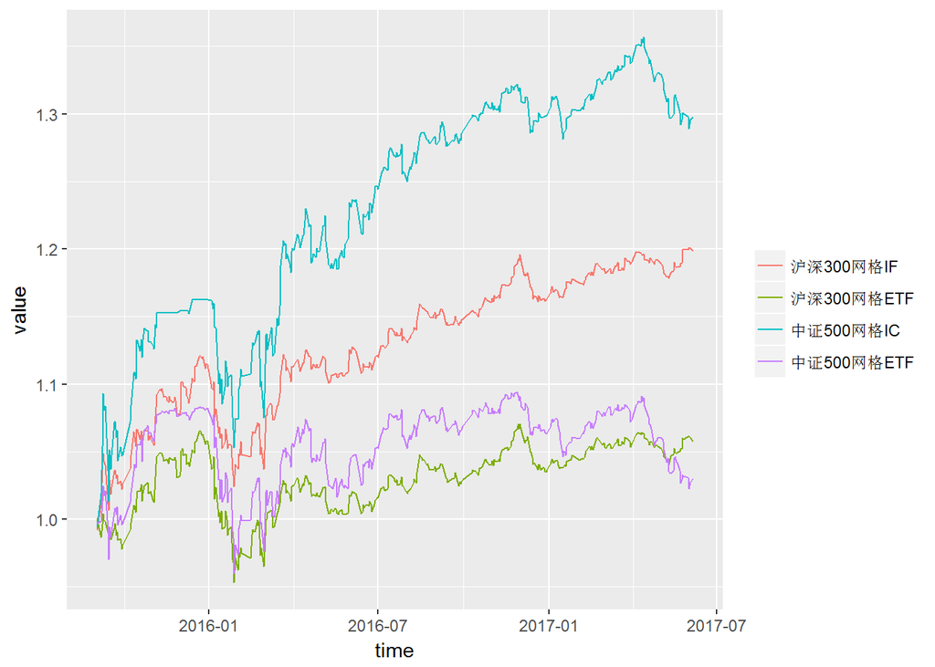

网格交易的收益统计如下表：

|  | 沪深300指数 | 沪深300网格IF | 沪深300网格ETF | 中证500指数 | 中证500网格IC | 中证500网格ETF |
| --- | --- | --- | --- | --- | --- | --- |
| 2015-09-02 ~ 2015-12-31 | 11.0% | 11.1% | 5.6% | 23.5% | 16.2% | 8.1% |
| 2016-01-04 ~ 2016-12-30 | -11.3% | 4.7% | -1.8% | -17.8% | 11.8% | -1.6% |
| 2017-01-03 ~ 2017-06-05 | 4.8% | 3.0% | 2.0% | -7.1% | -0.1% | -3.1% |
| 累计收益率 | 3.2% | 19.8% | 5.8% | -5.7% | 29.8% | 3.1% |
| 年化收益率 | 1.8% | 10.8% | 3.2% | -3.3% | 15.9% | 1.7% |
| 年化波动率 | 20.9% | 8.7% | 8.5% | 28.4% | 12.9% | 11.1% |
| 年化Sharpe值 | 8.6% | 123.7% | 38.0% | -11.6% | 123.3% | 15.5% |
| 最大回撤 | 26.4% | 8.6% | 10.5% | 33.5% | 9.4% | 11.4% |

## E、选股

### (e1)大小市值100

作为多因子选股的第一部分，有必要从市值因子说起。 下面利用总市值因子，在中证全指的成分股内，选出市值最大和最小的100只股票，这里剔除了ST、新上市、停牌和涨停的股票，等权配置，每月换仓一次，交易成本千分之三。观察历年来大、小市值组净值表现如下图。

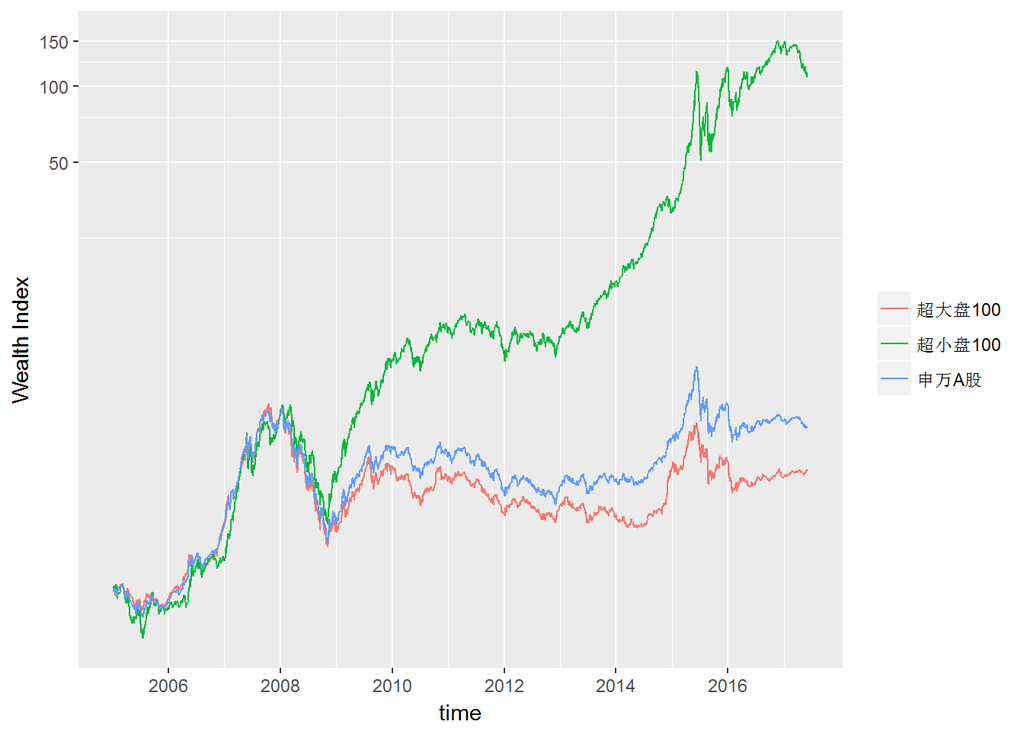

大小市值100的收益统计如下表：

|  | 超大盘100 | 超小盘100 | 申万A股 |
| --- | --- | --- | --- |
| 2005-01-05 ~ 2005-12-30 | -8.0% | -15.5% | -10.1% |
| 2006-01-04 ~ 2006-12-29 | 104.5% | 56.5% | 103.9% |
| 2007-01-04 ~ 2007-12-28 | 163.5% | 270.9% | 167.2% |
| 2008-01-02 ~ 2008-12-31 | -65.6% | -45.1% | -62.8% |
| 2009-01-05 ~ 2009-12-31 | 82.8% | 206.5% | 105.6% |
| 2010-01-04 ~ 2010-12-31 | -9.9% | 32.0% | -6.8% |
| 2011-01-04 ~ 2011-12-30 | -27.2% | -19.5% | -28.6% |
| 2012-01-04 ~ 2012-12-31 | 7.7% | 15.8% | 4.9% |
| 2013-01-04 ~ 2013-12-31 | -9.2% | 65.4% | 6.3% |
| 2014-01-02 ~ 2014-12-31 | 55.5% | 89.8% | 44.9% |
| 2015-01-05 ~ 2015-12-31 | 4.5% | 266.7% | 35.3% |
| 2016-01-04 ~ 2016-12-30 | -13.5% | 24.7% | -13.6% |
| 2017-01-03 ~ 2017-06-05 | 6.6% | -23.7% | -5.2% |
| 累计收益率 | 199.8% | 11020.8% | 345.9% |
| 年化收益率 | 9.2% | 46.1% | 12.8% |
| 年化波动率 | 29.0% | 35.7% | 28.5% |
| 年化Sharpe值 | 31.9% | 129.3% | 44.9% |
| 最大回撤 | 72.9% | 66.4% | 70.5% |

### (e2)银行股轮动

银行股轮动是参考集思录的热门贴银行股评级而来的，数据的提取和参数的设置和原贴有一定的差别，所以轮动的效果也会不太一样，不过回测的效果还不错，从现在开始跟踪。2013年以来银行股轮动的结果如下图：

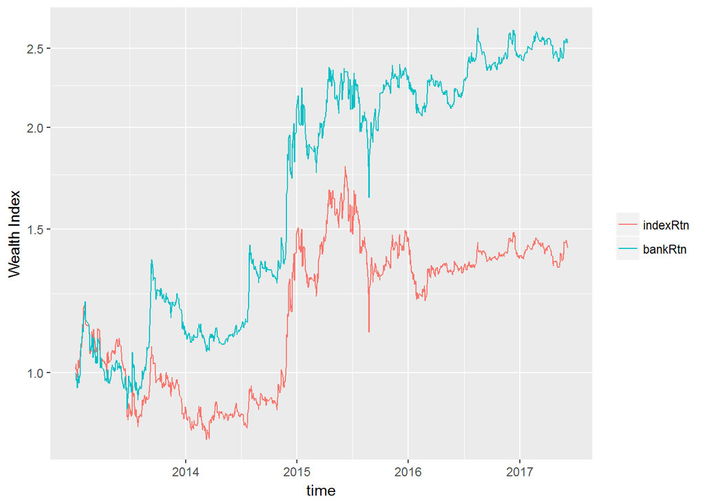

银行股轮动的收益统计如下表：

|  | 申万银行 | 银行股轮动 |
| --- | --- | --- |
| 2013-01-04 ~ 2013-12-31 | -9.2% | 12.5% |
| 2014-01-02 ~ 2014-12-31 | 63.2% | 87.6% |
| 2015-01-05 ~ 2015-12-31 | -1.4% | 9.4% |
| 2016-01-04 ~ 2016-12-30 | -4.9% | 6.2% |
| 2017-01-04 ~ 2017-06-05 | 2.4% | 3.4% |
| 累计收益率 | 42.3% | 153.8% |
| 年化收益率 | 8.3% | 23.4% |
| 年化波动率 | 27.8% | 29.7% |
| 年化Sharpe值 | 29.9% | 78.9% |
| 最大回撤 | 37.4% | 30.8% |

银行股轮动的最新得分如下表：

| 日期 | 代码 | 简称 | PB | ROE | 翻倍期 | 持仓 |
| --- | --- | --- | --- | --- | --- | --- |
| 2017-06-05 | EQ600015 | 华夏银行 | 0.75 | 0.13 | 3.4 | hold |
| 2017-06-05 | EQ601818 | 光大银行 | 0.74 | 0.12 | 3.6 |  |
| 2017-06-05 | EQ601328 | 交通银行 | 0.72 | 0.10 | 3.7 |  |
| 2017-06-05 | EQ601988 | 中国银行 | 0.76 | 0.11 | 3.9 |  |
| 2017-06-05 | EQ600016 | 民生银行 | 0.84 | 0.14 | 4.1 |  |
| 2017-06-05 | EQ000001 | 平安银行 | 0.77 | 0.11 | 4.1 |  |
| 2017-06-05 | EQ601288 | 农业银行 | 0.85 | 0.14 | 4.2 |  |
| 2017-06-05 | EQ601998 | 中信银行 | 0.78 | 0.11 | 4.4 |  |
| 2017-06-05 | EQ601398 | 工商银行 | 0.93 | 0.14 | 4.8 |  |
| 2017-06-05 | EQ601166 | 兴业银行 | 0.97 | 0.14 | 5.0 |  |
| 2017-06-05 | EQ601939 | 建设银行 | 0.98 | 0.14 | 5.0 |  |
| 2017-06-05 | EQ600000 | 浦发银行 | 0.98 | 0.14 | 5.1 |  |
| 2017-06-05 | EQ601169 | 北京银行 | 0.94 | 0.12 | 5.5 |  |
| 2017-06-05 | EQ601009 | 南京银行 | 1.06 | 0.13 | 5.9 |  |
| 2017-06-05 | EQ002142 | 宁波银行 | 1.38 | 0.16 | 6.9 |  |
| 2017-06-05 | EQ600036 | 招商银行 | 1.38 | 0.15 | 7.2 |  |
| 2017-06-05 | EQ601997 | 贵阳银行 | 1.71 | 0.17 | 7.7 |  |
| 2017-06-05 | EQ601229 | 上海银行 | 1.26 | 0.12 | 8.1 |  |
| 2017-06-05 | EQ600919 | 江苏银行 | 1.33 | 0.13 | 8.1 |  |
| 2017-06-05 | EQ600926 | 杭州银行 | 1.50 | 0.10 | 11.1 |  |
| 2017-06-05 | EQ601128 | 常熟银行 | 2.56 | 0.11 | 16.2 |  |
| 2017-06-05 | EQ600908 | 无锡银行 | 2.68 | 0.10 | 17.2 |  |
| 2017-06-05 | EQ002807 | 江阴银行 | 2.40 | 0.09 | 18.6 |  |
| 2017-06-05 | EQ603323 | 吴江银行 | 2.25 | 0.08 | 18.7 |  |
| 2017-06-05 | EQ002839 | 张家港行 | 3.66 | 0.09 | 24.2 |  |

## F、多因子跟踪

### (f1)近一个月周频因子IC

全市场因子IC表现如下图所示，根据因子IC均值大于0，胜率大于50%简单区分了一下alpha因子和风险因子。

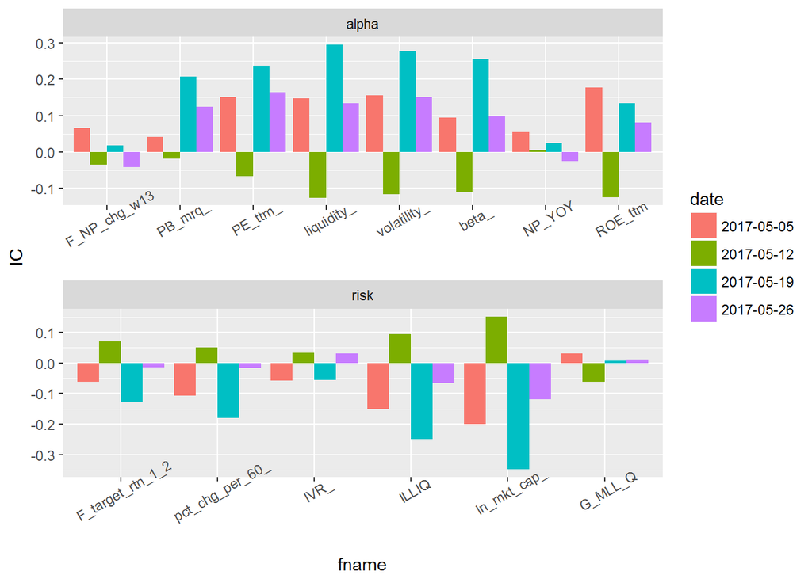

沪深300因子IC表现如下图所示。

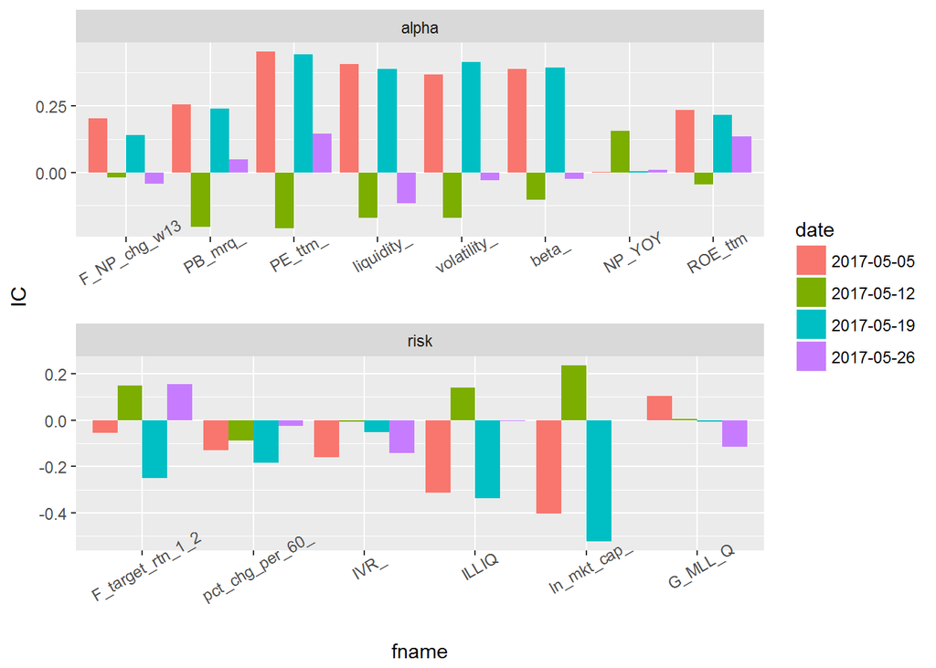

中证500因子IC表现如下图所示。

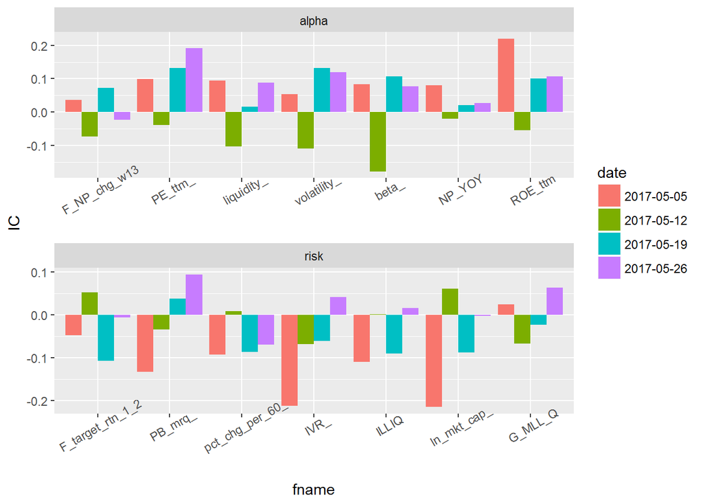

因子IC统计如下表所示。

| 因子名 | 全市场排名 | 全市场均值 | 全市场胜率 | 沪深300排名 | 沪深300均值 | 沪深300胜率 | 中证500排名 | 中证500均值 | 中证500胜率 |
| --- | --- | --- | --- | --- | --- | --- | --- | --- | --- |
| PE_ttm_ | 1 | 0.121 | 0.75 | 1 | 0.208 | 0.75 | 1 | 0.095 | 0.75 |
| volatility_ | 2 | 0.117 | 0.75 | 3 | 0.146 | 0.50 | 3 | 0.049 | 0.75 |
| liquidity_ | 3 | 0.113 | 0.75 | 5 | 0.127 | 0.50 | 5 | 0.024 | 0.75 |
| PB_mrq_ | 4 | 0.089 | 0.75 | 6 | 0.084 | 0.75 | 9 | -0.009 | 0.50 |
| beta_ | 5 | 0.084 | 0.75 | 2 | 0.163 | 0.50 | 6 | 0.022 | 0.75 |
| ROE_ttm | 6 | 0.067 | 0.75 | 4 | 0.135 | 0.75 | 2 | 0.093 | 0.75 |
| NP_YOY | 7 | 0.015 | 0.75 | 8 | 0.043 | 1.00 | 4 | 0.027 | 0.75 |
| F_NP_chg_w13 | 8 | 0.002 | 0.50 | 7 | 0.071 | 0.50 | 7 | 0.003 | 0.50 |
| G_MLL_Q | 9 | -0.003 | 0.75 | 10 | -0.003 | 0.50 | 8 | -0.001 | 0.50 |
| IVR_ | 10 | -0.013 | 0.50 | 11 | -0.090 | 0.00 | 14 | -0.075 | 0.25 |
| F_target_rtn_1_2 | 11 | -0.034 | 0.25 | 9 | -0.001 | 0.50 | 10 | -0.027 | 0.25 |
| pct_chg_per_60_ | 12 | -0.063 | 0.25 | 12 | -0.107 | 0.00 | 12 | -0.060 | 0.25 |
| ILLIQ | 13 | -0.093 | 0.25 | 13 | -0.128 | 0.25 | 11 | -0.046 | 0.50 |
| ln_mkt_cap_ | 14 | -0.129 | 0.25 | 14 | -0.172 | 0.50 | 13 | -0.061 | 0.25 |

### (f2)近一个月周频因子分组超额收益

全市场，不同时间段，根据因子得分分为10组，得分最高的组**超额**收益率如下图所示，根据累计收益率大于0和区间收益率为正概率大于0.5,简单区分了alpha因子和风险因子。

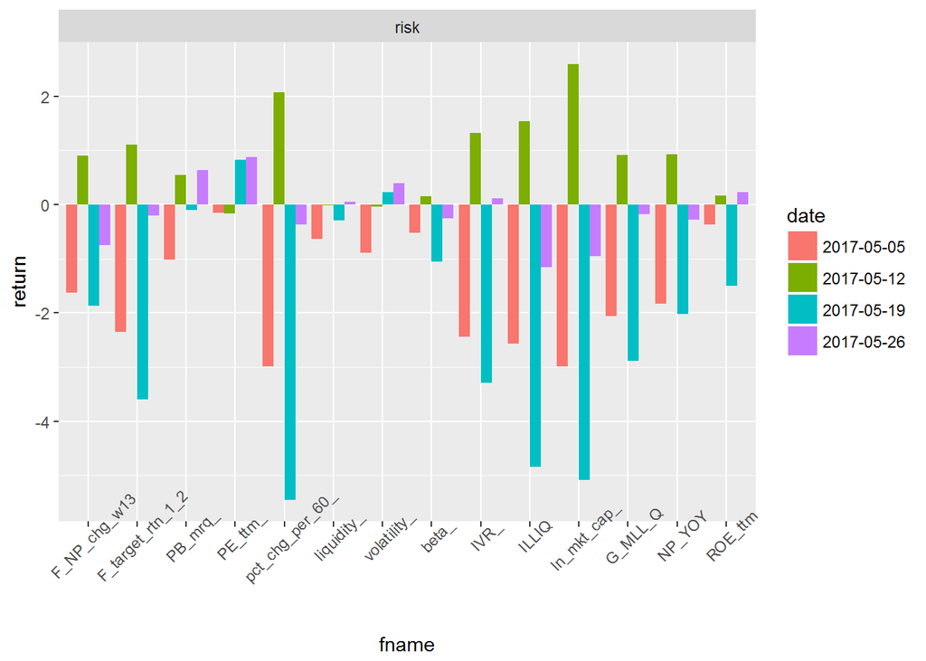

沪深300内得分最高的组**超额**收益率如下图所示。

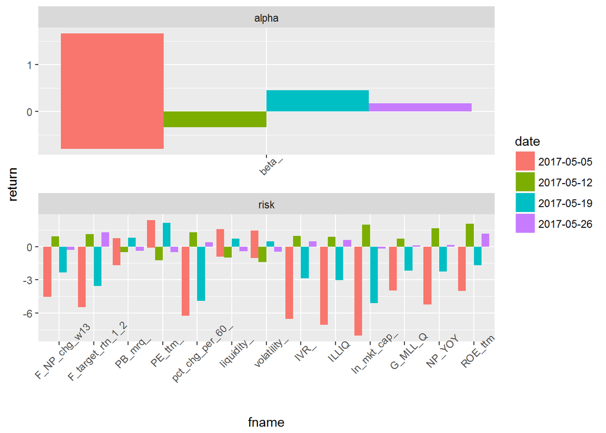

[figure not shown]

各个样本空间内，因子得分最高的一组和得分最低的一组的**超额**累积收益率统计如下表所示。

| 因子名 | 全市场Q1 | 全市场Q10 | 沪深300Q1 | 沪深300Q10 | 中证500Q1 | 中证500Q10 |
| --- | --- | --- | --- | --- | --- | --- |
| PE_ttm_ | 1.3 | -10.8 | 2.7 | -19.9 | 3.5 | -2.1 |
| PB_mrq_ | -0.9 | -9.4 | -1.0 | -11.1 | 1.0 | 2.4 |
| volatility_ | -1.1 | -12.8 | -1.0 | -15.4 | -0.4 | -5.1 |
| liquidity_ | -1.4 | -12.0 | 0.0 | -17.0 | -0.6 | -3.4 |
| ROE_ttm | -1.7 | -9.6 | -4.0 | -12.6 | 4.0 | -2.9 |
| beta_ | -2.1 | -9.0 | 1.1 | -15.4 | 0.0 | -1.5 |
| F_NP_chg_w13 | -4.8 | -5.6 | -8.2 | -13.7 | 1.5 | 0.4 |
| NP_YOY | -4.9 | -7.1 | -8.3 | -11.9 | 1.2 | -3.1 |
| G_MLL_Q | -6.0 | -5.7 | -6.7 | -8.7 | -1.5 | -3.3 |
| IVR_ | -6.5 | -4.3 | -11.6 | -1.5 | -3.4 | 4.0 |
| F_target_rtn_1_2 | -7.1 | -4.9 | -9.5 | -12.4 | -0.3 | 3.9 |
| ln_mkt_cap_ | -9.1 | 2.6 | -16.2 | 2.1 | -2.2 | 4.3 |
| ILLIQ | -9.2 | -0.3 | -12.8 | -1.0 | -5.6 | -0.4 |
| pct_chg_per_60_ | -9.4 | -4.0 | -12.8 | -5.3 | -2.8 | 2.4 |

### (f3)近一年月频因子IC

全市场因子IC表现如下图所示。

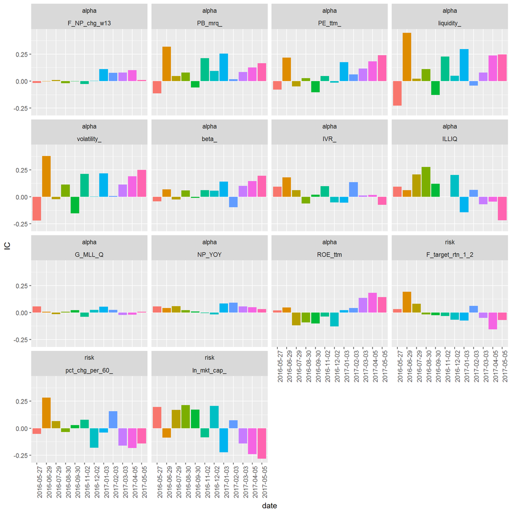

沪深300因子IC表现如下图所示。

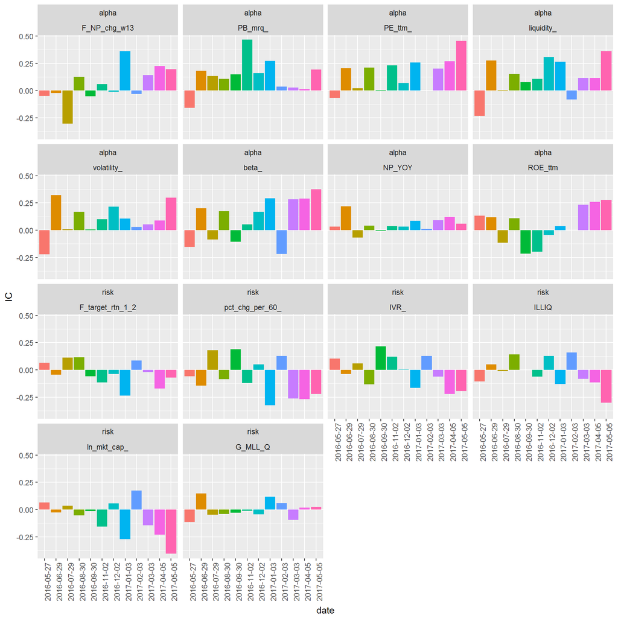

中证500因子IC表现如下图所示。

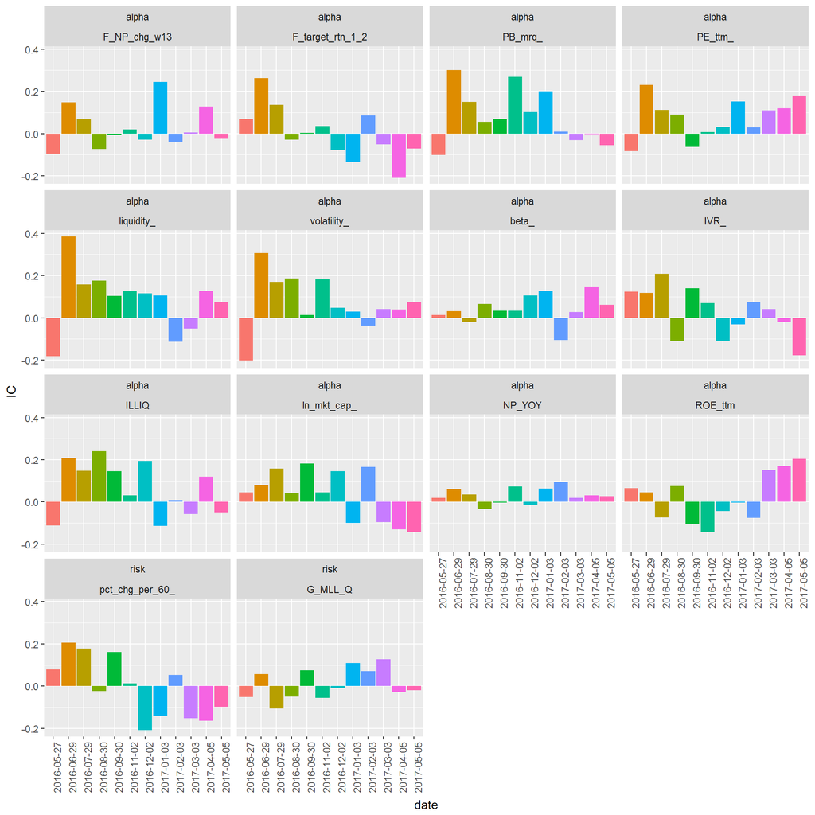

因子IC统计如下表所示。

|  | 因子名 | 全市场排名 | 全市场均值 | 全市场胜率 | 沪深300排名 | 沪深300均值 | 沪深300胜率 | 中证500排名 | 中证500均值 | 中证500胜率 |
| --- | --- | --- | --- | --- | --- | --- | --- | --- | --- | --- |
| 15 | liquidity_ | 1 | 0.110 | 0.75 | 3 | 0.121 | 0.75 | 1 | 0.086 | 0.75 |
| 16 | PB_mrq_ | 2 | 0.102 | 0.83 | 2 | 0.131 | 0.92 | 2 | 0.081 | 0.67 |
| 17 | volatility_ | 3 | 0.090 | 0.75 | 5 | 0.098 | 0.92 | 4 | 0.071 | 0.83 |
| 18 | PE_ttm_ | 4 | 0.068 | 0.67 | 1 | 0.154 | 0.83 | 3 | 0.076 | 0.83 |
| 19 | beta_ | 5 | 0.055 | 0.67 | 4 | 0.107 | 0.67 | 6 | 0.044 | 0.83 |
| 20 | ILLIQ | 6 | 0.046 | 0.58 | 11 | -0.028 | 0.33 | 5 | 0.064 | 0.67 |
| 21 | NP_YOY | 7 | 0.040 | 0.83 | 6 | 0.055 | 0.83 | 8 | 0.031 | 0.75 |
| 22 | IVR_ | 8 | 0.031 | 0.67 | 10 | -0.015 | 0.50 | 10 | 0.027 | 0.58 |
| 23 | F_NP_chg_w13 | 9 | 0.027 | 0.58 | 7 | 0.053 | 0.50 | 9 | 0.029 | 0.50 |
| 24 | ROE_ttm | 10 | 0.009 | 0.58 | 8 | 0.050 | 0.58 | 11 | 0.022 | 0.50 |
| 25 | G_MLL_Q | 11 | 0.008 | 0.67 | 9 | -0.002 | 0.42 | 12 | 0.010 | 0.42 |
| 26 | ln_mkt_cap_ | 12 | -0.002 | 0.50 | 14 | -0.081 | 0.33 | 7 | 0.033 | 0.67 |
| 27 | F_target_rtn_1_2 | 13 | -0.011 | 0.33 | 12 | -0.032 | 0.33 | 13 | 0.002 | 0.50 |
| 28 | pct_chg_per_60_ | 14 | -0.015 | 0.42 | 13 | -0.079 | 0.33 | 14 | -0.008 | 0.50 |

### (f4)近一年月频因子分组超额收益

全市场，不同时间段，根据因子得分分为10组，得分最高的组**超额**收益率如下图所示，根据累计收益率大于0和区间收益率为正概率大于0.5,简单区分了alpha因子和风险因子。

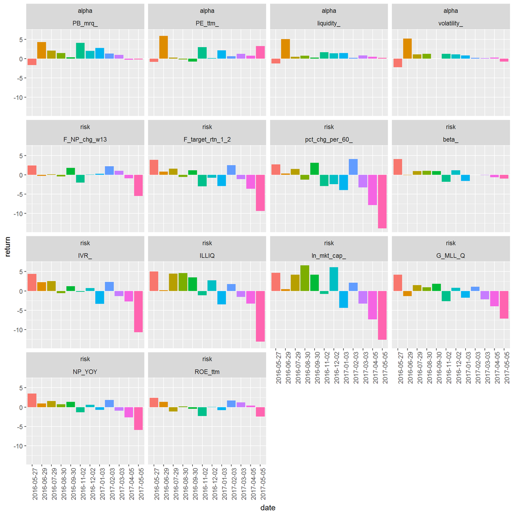

沪深300内得分最高的组**超额**收益率如下图所示。

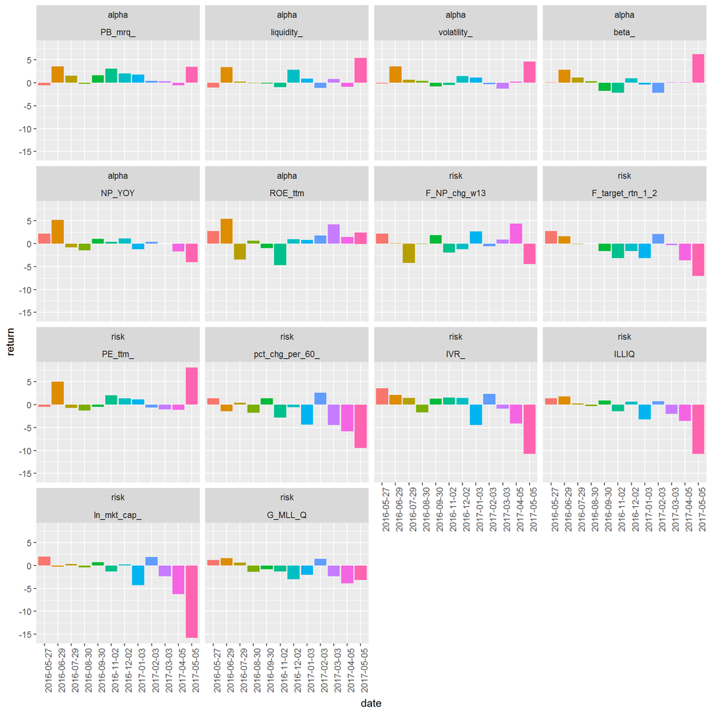

中证500内得分最高的组**超额**收益率如下图所示。

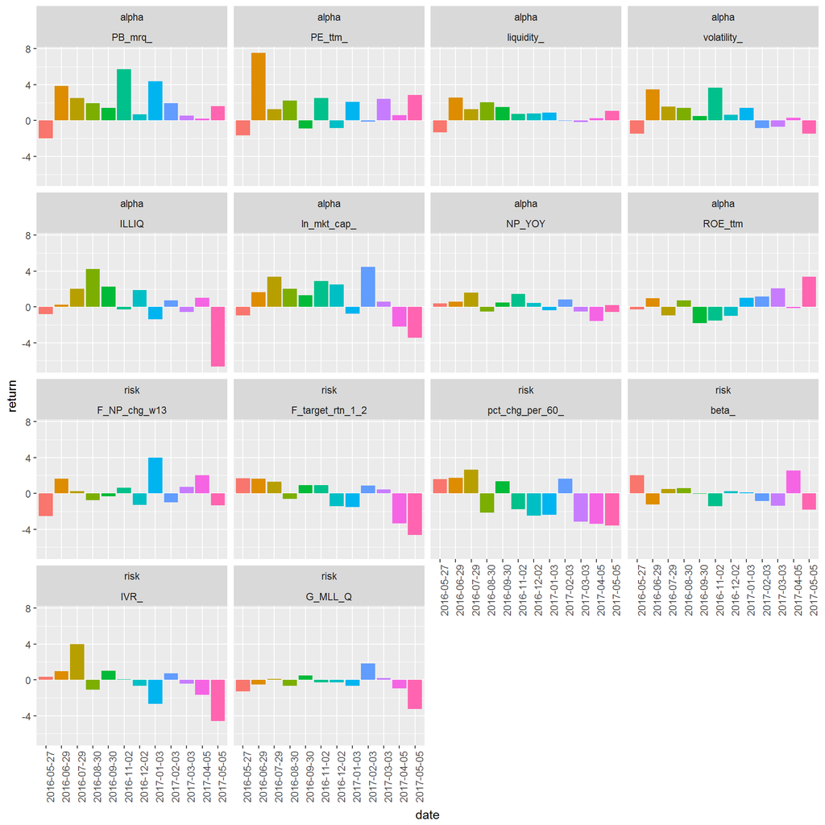

各个样本空间内，因子得分最高的一组和得分最低的一组的**超额**累积收益率统计如下表所示。

|  | 因子名 | 全市场Q1 | 全市场Q10 | 沪深300Q1 | 沪深300Q10 | 中证500Q1 | 中证500Q10 |
| --- | --- | --- | --- | --- | --- | --- | --- |
| 15 | PB_mrq_ | 18.2 | -26.5 | 17.9 | -23.5 | 25.2 | -5.5 |
| 16 | PE_ttm_ | 16.3 | -19.3 | 12.3 | -30.9 | 19.1 | -9.0 |
| 17 | liquidity_ | 11.9 | -34.2 | 9.7 | -28.6 | 9.9 | -18.7 |
| 18 | volatility_ | 8.3 | -27.7 | 9.2 | -20.9 | 8.6 | -15.7 |
| 19 | beta_ | 2.7 | -25.3 | 5.3 | -32.5 | -0.9 | -21.4 |
| 20 | ROE_ttm | -0.1 | -10.3 | 11.6 | -7.8 | 3.6 | -3.3 |
| 21 | ILLIQ | -1.1 | -6.8 | -15.0 | 9.0 | 2.5 | -18.9 |
| 22 | NP_YOY | -1.2 | -14.1 | 1.0 | -16.3 | 2.4 | -8.4 |
| 23 | F_NP_chg_w13 | -1.3 | -9.5 | -0.6 | -14.5 | 1.8 | -7.5 |
| 24 | ln_mkt_cap_ | -1.6 | 8.7 | -23.4 | 14.9 | 11.8 | 1.6 |
| 25 | IVR_ | -5.7 | -9.4 | -8.4 | 2.9 | -4.2 | 0.0 |
| 26 | G_MLL_Q | -8.6 | -9.2 | -12.4 | -8.4 | -5.2 | -4.4 |
| 27 | F_target_rtn_1_2 | -11.1 | -3.5 | -13.5 | -9.7 | -4.0 | 1.2 |
| 28 | pct_chg_per_60_ | -22.1 | -10.6 | -22.7 | 4.4 | -9.9 | -8.7 |